# MAT02014 - Planejamento de Experimentos II Delineamentos com fatores fixos e aleatórios

Rodrigo Citton P. dos Reis `rodrigocpdosreis@gmail.com` Universidade Federal do Rio Grande do Sul Instituto de Matemática e Estatística Departamento de Estatística

Porto Alegre, 2018

## Introdução

- Algumas vezes, nos delineamentos fatoriais cruzados, (efeitos de) fatores aleatórios são também introduzidos no modelo **pela forma que o experimento é conduzido**.

## Exemplo

### Resíduos de pesticidas em plantas de algodão

[figure not shown]

## Exemplo

### Resíduos de pesticidas em plantas de algodão

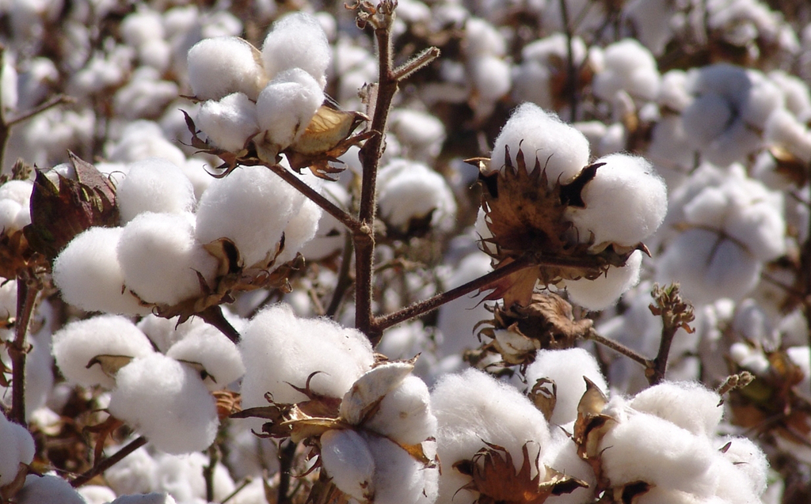

## Exemplo

### Resíduos de pesticidas em plantas de algodão

- Experimento comparando diferentes **formulações** e **métodos de aplicação** de um pesticida às folhas de plantas de algodão.
- O objetivo era **aumentar a quantidade de pesticida ativo** restante nas folhas da planta de algodão uma semana após a aplicação.
- O pesticida que está sendo estudado degrada na luz solar e um certo aditivo para a formulação retarda esse processo.
- Diferentes técnicas de aplicação podem diferir na quantidade de pesticida entregue às folhas da planta.

## Exemplo

### Resíduos de pesticidas em plantas de algodão

- Os **fatores de tratamento** neste experimento foram:
  - **duas formulações** diferentes do pesticida;
  - **dois métodos de aplicação** diferentes;
- Experimento fatorial $2^2$.
- A **unidade experimental** era uma fileira de 20 pés de algodão chamada de parcela, porque essa era uma área conveniente dentro da qual a aplicação de pesticidas podia ser controlada.

## Exemplo

### Resíduos de pesticidas em plantas de algodão

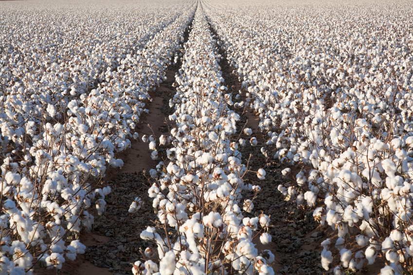

## Exemplo

### Resíduos de pesticidas em plantas de algodão

- Oito parcelas foram selecionadas e duas foram aleatoriamente designadas para cada uma das quatro combinações de tratamento, resultando em **duas repetições** por combinação de tratamento.
- Uma semana após a aplicação, os pesquisadores estavam prontos para determinar o resíduo de pesticida remanescente nas folhas da planta.
- No entanto, havia muito material vegetal em um lote inteiro para ser enviado ao laboratório para análise.
- Portanto, **duas amostras de folhas** em uma quantidade conveniente para análise laboratorial de resíduos de pesticidas foram selecionadas de cada parcela.

## Exemplo

### Resíduos de pesticidas em plantas de algodão

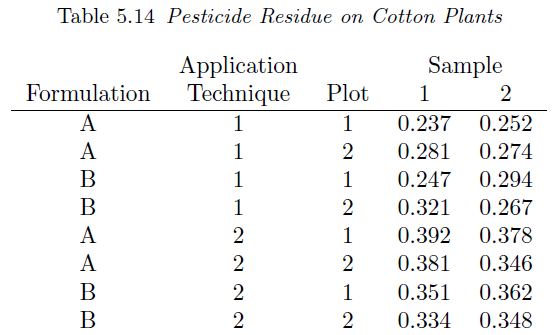

## Exemplo

- A formulação, a técnica de aplicação e sua interação são **fatores fixos** porque os pesquisadores estavam interessados em comparar a resposta média entre os níveis desses fatores.
- A parcela, por outro lado, é um **fator aleatório** que representa diferenças em unidades experimentais.
  - Está aninhado nas combinações de formulação por técnica de aplicação. - Não há interesse em comparar unidades experimentais dentro de cada combinação de formulação e aplicação.
  - Em vez disso, múltiplas parcelas por combinação de tratamento foram incluídas no delineamento, de modo que a **variação causada por diferentes parcelas** pudesse ser estimada e usada para avaliar a significância dos efeitos de formulação e aplicação.

## Exemplo

- As amostras replicadas (as folhas de algodão; subamostras) de cada parcela foram por conveniência na condução do experimento.
- A maneira mais simples de analisar os dados seria calcular a média das duas subamostras e proceder conforme uma análise de delineamentos fatoriais cruzados.
- No entanto, se as subamostras puderem ser consideradas independentes e for desejável incluir todos os dados na análise, um termo adicional para amostra deve ser incluído no modelo.
- Amostra é outro **efeito aleatório**, uma vez que não há interesse específico em comparar a resposta entre as duas amostras de cada parcela.

## Exemplo

[figure not shown]

$$y_{ijkl} = \mu + \alpha_i + \beta_j + \alpha\beta_{ij} + p_{(ij)k} + \epsilon_{ijkl},$$

em que $y_{ijkl}$ é o resíduo de pesticida encontrado na $l$-ésima amostra retirada da $k$-ésima parcela, tratado com nível de formulação $i$ e técnica de aplicação $j$.

## Exemplo

- Em geral $i = 1, \ldots,a, j = 1,\ldots, b, k = 1,\ldots, r$ e $l = 1,\ldots, s$.
  - Neste exemplo específico, $a = 2$, $b = 2$, $r = 2$, e $s = 2$;
  - $\alpha_i$ é o efeito da formulação;
  - $\beta_j$ é o efeito da aplicação;
  - $\alpha\beta_{ij}$ é o efeito de interação;
  - $p_{(ij)k}$ é o efeito de parcela aleatória;
  - $\epsilon_{ijkl}$ é o efeito da amostra aleatória.

## Exemplo (modelo na forma matricial)

[figure not shown]

$$\mathbf{y} = \mathbf{X}\boldsymbol{\beta} + \mathbf{Z}\boldsymbol{\gamma} + \boldsymbol{\epsilon},$$

## Exemplo (modelo na forma matricial)

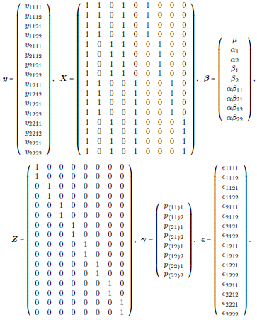

## Exemplo (modelo na forma matricial)

- $\boldsymbol{\beta}$ é um vetor de efeitos fixos.
- $\boldsymbol{\gamma}$ e $\boldsymbol{\epsilon}$ representam vetores de efeitos aleatórios.
- $\boldsymbol{\gamma}\sim MVN(\mathbf{0}, \sigma^2_p\mathbf{I}_{abr})$ independente de $\boldsymbol{\epsilon}\sim MVN(\mathbf{0}, \sigma^2\mathbf{I}_{abrs})$.
  - $\mathbf{y}\sim MVN(\mathbf{X}\boldsymbol{\beta}, \mathbf{V})$, em que $\mathbf{V} = \mathbf{Z}\sigma^2_p\mathbf{I}_{abr}\mathbf{Z}^{'} + \sigma^2\mathbf{I}_{abrs}$.
- Estimador de mínimos quadrados de $\boldsymbol{\beta}$ seria $\hat{\boldsymbol{\beta}} = (\mathbf{X}^{'}\mathbf{V}^{-}\mathbf{X})^{-}\mathbf{X}^{'}\mathbf{V}^{-}\mathbf{y}$.
  - **Problema:** $\sigma^2$ e $\sigma^2_p$ são desconhecidos, logo $\mathbf{V}$ também é.
  - **Solução:** tratar $\boldsymbol{\beta}$ e $\boldsymbol{\gamma}$ como fixos.

## Exemplo (R)

```r
library(daewr)
data(pesticide)
head(pesticide)
```

```
##   form tech plot residue
## 1    A    1    1   0.237
## 2    A    1    1   0.252
## 3    A    1    2   0.281
## 4    A    1    2   0.274
## 5    B    1    1   0.247
## 6    B    1    1   0.294
```

```r
tail(pesticide)
```

```
##    form tech plot residue
## 11    A    2    2   0.381
## 12    A    2    2   0.346
## 13    B    2    1   0.351
## 14    B    2    1   0.362
## 15    B    2    2   0.334
## 16    B    2    2   0.348
```

## Exemplo (R)

```r
mod4 <- aov(residue ~ form + tech + form:tech + plot:form:tech,
            data = pesticide)
summary(mod4)
```

```
##                Df  Sum Sq Mean Sq F value   Pr(>F)
## form            1 0.00002 0.00002   0.040   0.8455
## tech            1 0.03231 0.03231  72.434 2.79e-05 ***
## form:tech       1 0.00219 0.00219   4.900   0.0578 .
## form:tech:plot  4 0.00234 0.00059   1.314   0.3432
## Residuals       8 0.00357 0.00045
## ---
## Signif. codes:  0 '***' 0.001 '**' 0.01 '*' 0.05 '.' 0.1 ' ' 1
```

- Testes $F$ e valores de $p$ estão incorretos!

## Exemplo

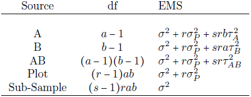

## Exemplo (R)

- Valores de $F$ corretos:

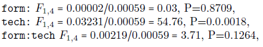

```r
pf(0.03, 1, 4, lower.tail = FALSE)
```

```
## [1] 0.8709017
```

- **O que concluímos?**

## Exemplo (R)

```r
# Example 23 p. 178
library(lme4)
c1 <- c( -.5, .5 )
mod5 <- lmer(residue ~ 1 + form + tech + form:tech + (1|plot:form:tech),
             contrasts = list( form = c1, tech = c1),
             data = pesticide)
summary(mod5)
```

```
## Linear mixed model fit by REML ['lmerMod']
## Formula: residue ~ 1 + form + tech + form:tech + (1 | plot:form:tech)
##    Data: pesticide
##
## REML criterion at convergence: -51.9
##
## Scaled residuals:
##      Min       1Q   Median       3Q      Max
## -1.53621 -0.67181  0.05407  0.57711  1.70193
##
## Random effects:
##  Groups         Name        Variance  Std.Dev.
##  plot:form:tech (Intercept) 6.994e-05 0.008363
##  Residual                   4.461e-04 0.021120
## Number of obs: 16, groups:  plot:form:tech, 8
##
## Fixed effects:
##              Estimate Std. Error t value
## (Intercept)  0.316562   0.006052   52.31
## form1       -0.002125   0.012103   -0.18
## tech1        0.089875   0.012103    7.43
## form1:tech1 -0.046750   0.024206   -1.93
##
## Correlation of Fixed Effects:
##             (Intr) form1 tech1
## form1       0.000
## tech1       0.000  0.000
## form1:tech1 0.000  0.000 0.000
```

## Exemplo (R): testes F para os fatores fixos

```r
# Example 25 p. 179
anova(mod5)
```

```
## Analysis of Variance Table
##           Df    Sum Sq   Mean Sq F value
## form       1 0.0000138 0.0000138  0.0308
## tech       1 0.0245970 0.0245970 55.1425
## form:tech  1 0.0016638 0.0016638  3.7300
```

## Exemplo (R): comparações ajustadas

```r
# Example 24 p. 178
library(lsmeans)
lsmeans(mod5, pairwise ~ tech, adjust = c("tukey"))
```

```
## $lsmeans
##  tech   lsmean          SE df  lower.CL  upper.CL
##  1    0.271625 0.008558165  4 0.2478637 0.2953863
##  2    0.361500 0.008558165  4 0.3377387 0.3852613
##
## Results are averaged over the levels of: form
## Degrees-of-freedom method: satterthwaite
## Confidence level used: 0.95
##
## $contrasts
##  contrast  estimate         SE df t.ratio p.value
##  1 - 2    -0.089875 0.01210307  4  -7.426  0.0018
##
## Results are averaged over the levels of: form
```

## Exemplo (R): EBLUPs

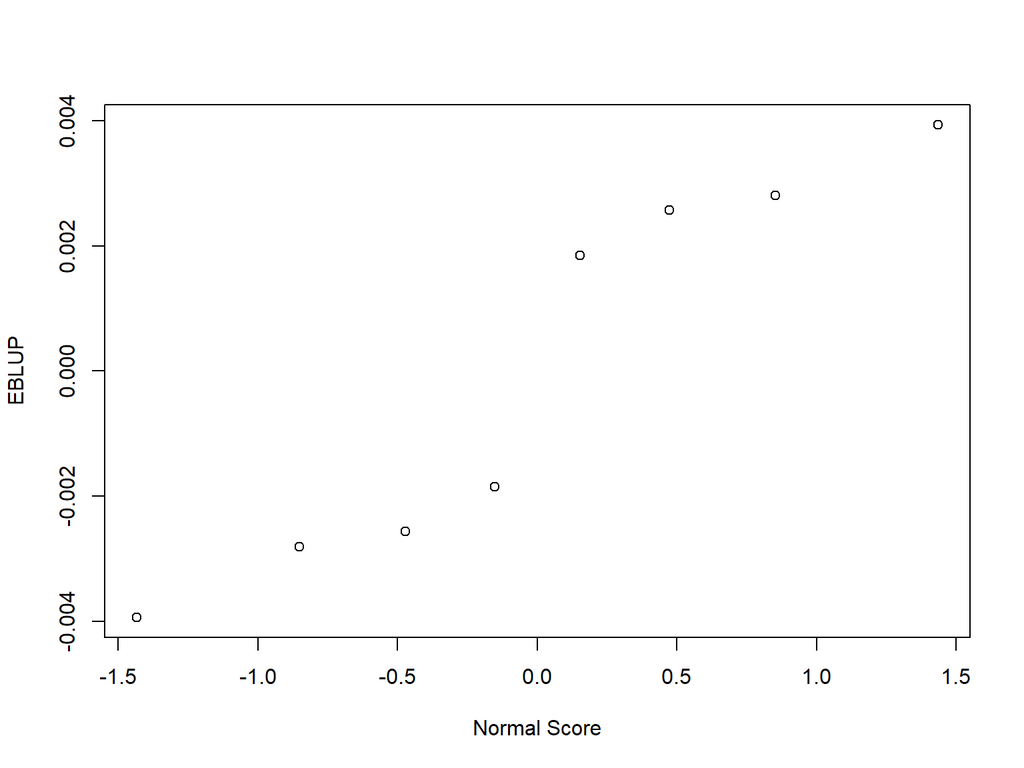

```r
qqnorm( ranef(mod5)$`plot:form:tech`[[1]],
        main = "", ylab = "EBLUP",
        xlab = "Normal Score" )
```

## Conclusões

- Modelos como o que vimos são chamados de **modelos de efeitos mistos**.
- Neste exemplo, a aplicação do pesticida a cada parcela pode induzir uma correlação entre sub-amostras da mesma parcela.
  - Embora a suposição de independência seja violada, o teste $F$ em efeitos fixos utilizando o quadrado médio da parcela como o denominador ainda é válido.

[figure not shown]